# HW02

Shijie An

2022-09-14

## 1.

```r
path <- "states.csv"
states <- read.csv(path)
```

```r
income <- states[[3]]
income
```

```
##  [1] 3624 6315 4530 3378 5114 4884 5348 4809 4815 4091 4963 4119 5107 4458 4628
## [16] 4669 3712 3545 3694 5299 4755 4751 4675 3098 4254 4347 4508 5149 4281 5237
## [31] 3601 4903 3875 5087 4561 3983 4660 4449 4558 3635 4167 3821 4188 4022 3907
## [46] 4701 4864 3617 4468 4566
```

```r
length <- length(income)
length
```

```
## [1] 50
```

```r
class(income)
```

```
## [1] "integer"
```

```r
colnames(states[3])
```

```
## [1] "Income"
```

## 2.

```r
## the 5th element
states[5, ]
```

```
##       States Population Income Illiteracy Life.Exp Murder HS.Grad Frost   Area
## 5 California      21198   5114        1.1    71.71   10.3    62.6    20 156361
##   Abbrev Region
## 5     CA   West
```

```r
## the 50th element
states[50, ]
```

```
##     States Population Income Illiteracy Life.Exp Murder HS.Grad Frost  Area
## 50 Wyoming        376   4566        0.6    70.29    6.9    62.9   173 97203
##    Abbrev Region
## 50     WY   West
```

```r
## 40th through 50th elements
states[40:50, ]
```

```
##            States Population Income Illiteracy Life.Exp Murder HS.Grad Frost
## 40 South Carolina       2816   3635        2.3    67.96   11.6    37.8    65
## 41   South Dakota        681   4167        0.5    72.08    1.7    53.3   172
## 42      Tennessee       4173   3821        1.7    70.11   11.0    41.8    70
## 43          Texas      12237   4188        2.2    70.90   12.2    47.4    35
## 44           Utah       1203   4022        0.6    72.90    4.5    67.3   137
## 45        Vermont        472   3907        0.6    71.64    5.5    57.1   168
## 46       Virginia       4981   4701        1.4    70.08    9.5    47.8    85
## 47     Washington       3559   4864        0.6    71.72    4.3    63.5    32
## 48  West Virginia       1799   3617        1.4    69.48    6.7    41.6   100
## 49      Wisconsin       4589   4468        0.7    72.48    3.0    54.5   149
## 50        Wyoming        376   4566        0.6    70.29    6.9    62.9   173
##      Area Abbrev        Region
## 40  30225     SC         South
## 41  75955     SD North Central
## 42  41328     TN         South
## 43 262134     TX         South
## 44  82096     UT          West
## 45   9267     VT     Northeast
## 46  39780     VA         South
## 47  66570     WA          West
## 48  24070     WV         South
## 49  54464     WI North Central
## 50  97203     WY          West
```

## 3. boxplots

Base R boxplot

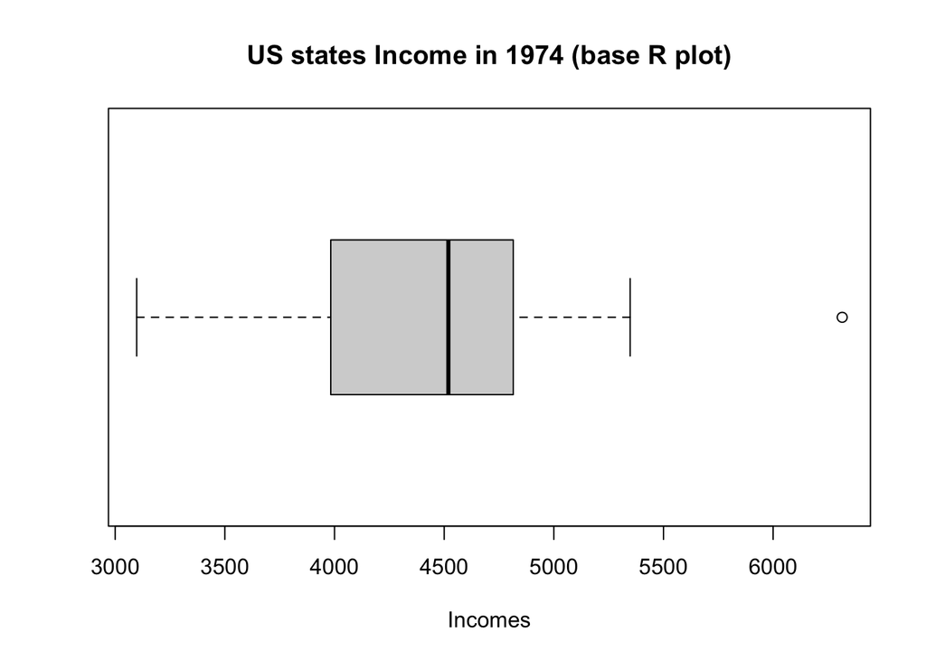

```r
boxplot(income,
        horizontal = TRUE,
        xlab = "Incomes",
        main = "US states Income in 1974 (base R plot)")
```

ggplot 2

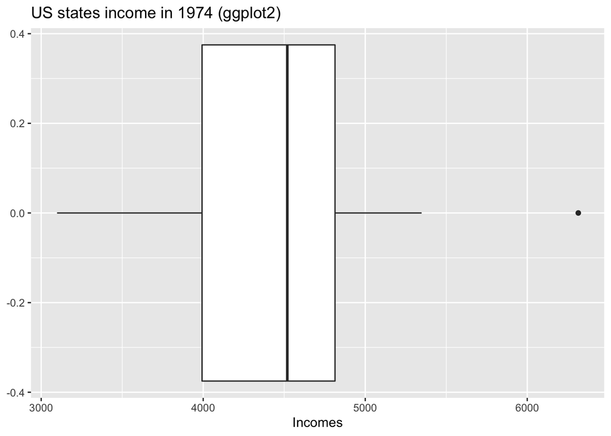

```r
library(ggplot2)
ggplot(data = states, mapping = aes(x = income)) +
  geom_boxplot() +
  xlab("Incomes") +
  ggtitle("US states income in 1974 (ggplot2)")
```

```r
median(income)
```

```
## [1] 4519
```

```r
quantile(income, probs = c(.25, .5, .75))
```

```
##     25%     50%     75%
## 3992.75 4519.00 4813.50
```

```r
## so we have IQR = .75 - .25
# So Q1 = 3992.75, Q2 = 4519, Q3 = 4813.5
IQR <- 4813.50 - 3992.75
IQR
```

```
## [1] 820.75
```

```r
# So we have IQR = Q3 - Q1 = 820.75
# so the lower fence should be Q1 - 1.5 * IQR, which is:
lower_fence <- 3992.75 - 1.5 * 820.75
lower_fence
```

```
## [1] 2761.625
```

```r
# And upper fence should be Q3 + 1.5 * IQR, which is:
upper_fence <- 4813.50 + 1.5 * 820.75
upper_fence
```

```
## [1] 6044.625
```

```r
# So we can see that the lowest value, which is 3098, is within the lower fence of the income.
# And the greatest number 6315 is beyond the upper fence, so it is an outlier.
# So the second greatest income, 5348, is the greatest normal value showing in the boxplot.
```

## 4. histograms

Base R histogram

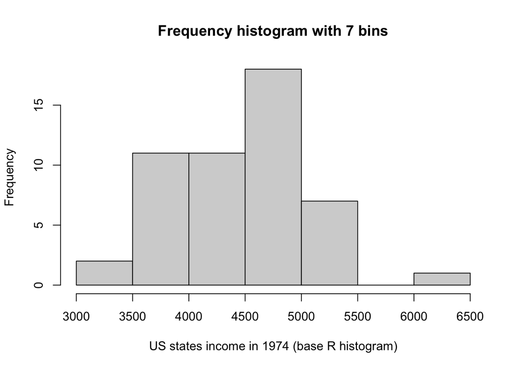

```r
hist(income, breaks = seq(3000, 6500, 500),
     xlab = "US states income in 1974 (base R histogram)",
     main = "Frequency histogram with 7 bins")
```

ggplot2 histogram

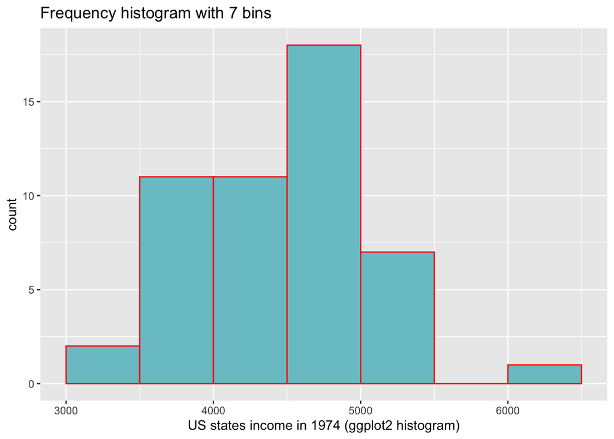

```r
ggplot(data = states, mapping = aes(x = income)) +
  geom_histogram(breaks = seq(3000, 6500, 500),
                 col = "red", fill = "cadetblue3") +
  xlab("US states income in 1974 (ggplot2 histogram)") +
  ggtitle("Frequency histogram with 7 bins")
```

Or we have have the histograms with 14 bins, so that will be like:

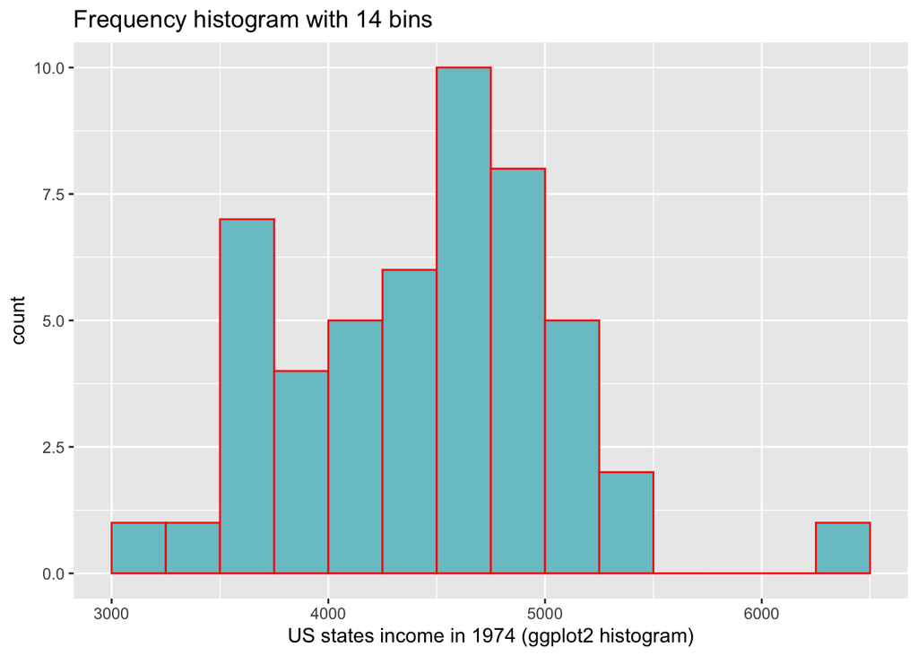

```r
ggplot(data = states, mapping = aes(x = income)) +
  geom_histogram(breaks = seq(3000, 6500, 250),
                 col = "red", fill = "cadetblue3") +
  xlab("US states income in 1974 (ggplot2 histogram)") +
  ggtitle("Frequency histogram with 14 bins")
```

For the 7 and 14 bins of histogram, I prefer the 14th, because it looks more clear. And with higher frequencies you will see different sections of income more clear.

## 5. kernel density plots

Base R kernel density plot

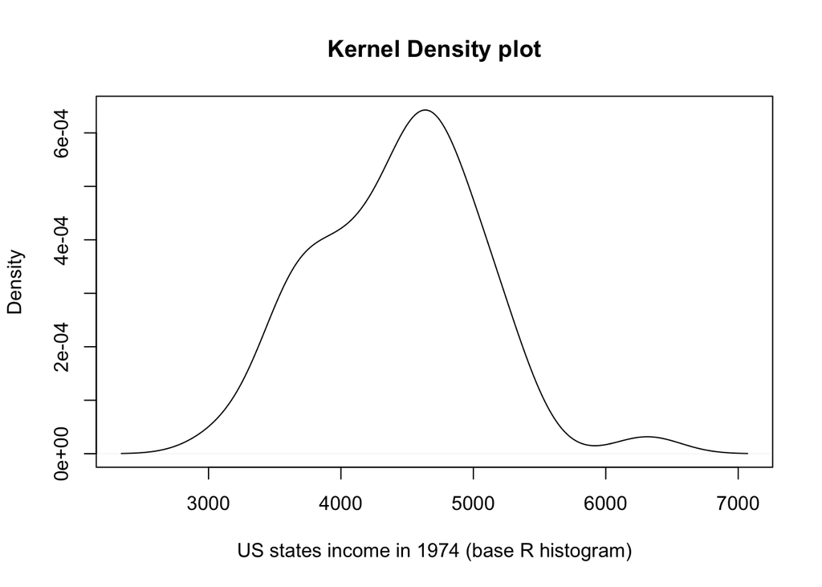

```r
plot(density(income),
     xlab = "US states income in 1974 (base R histogram)",
     main = "Kernel Density plot")
```

ggplot2 kernel density plot

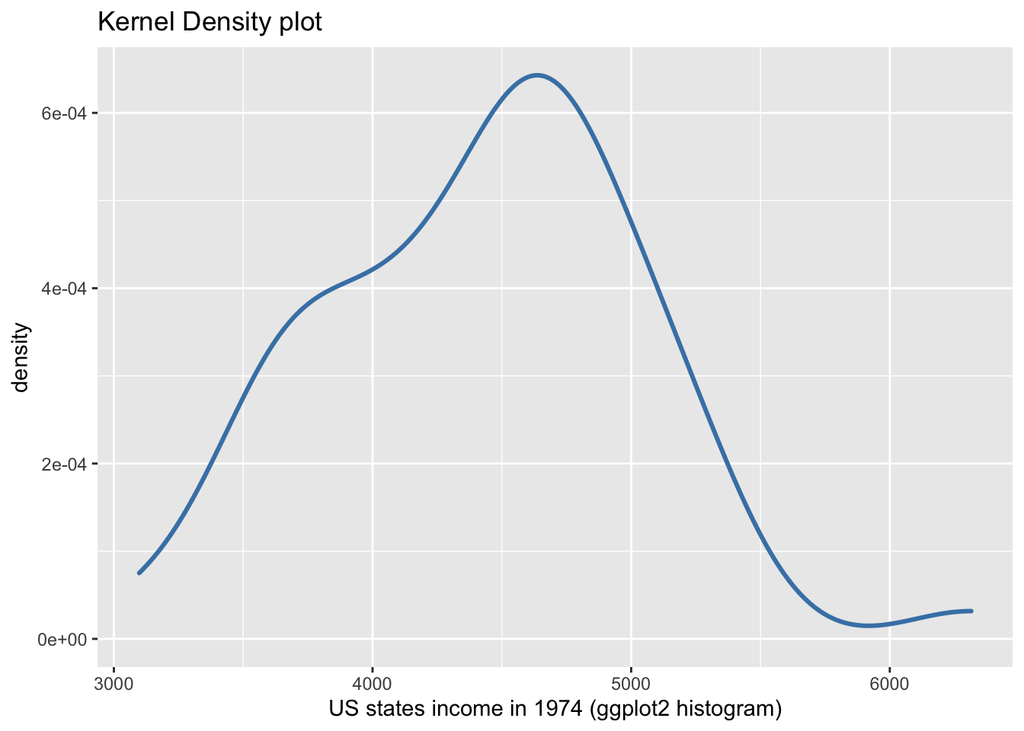

```r
ggplot(data = states, mapping = aes(x = income)) +
  geom_density(col = "steelblue", lwd = 1.05) +
  xlab("US states income in 1974 (ggplot2 histogram)") +
  ggtitle("Kernel Density plot")
```

The difference between kernel density plot and histogram is that the histogram looks more like being visualized by the discrete data, but kernel density plot looks more like a continuous data. The kernel density plot is more likely to separate the bins in the histogram so that every “bin” of kernel density plot is some close number, so that the kernel looks to be more smooth. Histogram looks like a Riemann sum of the kernel density plot.

## 6. QQ plots

Base R QQ plot

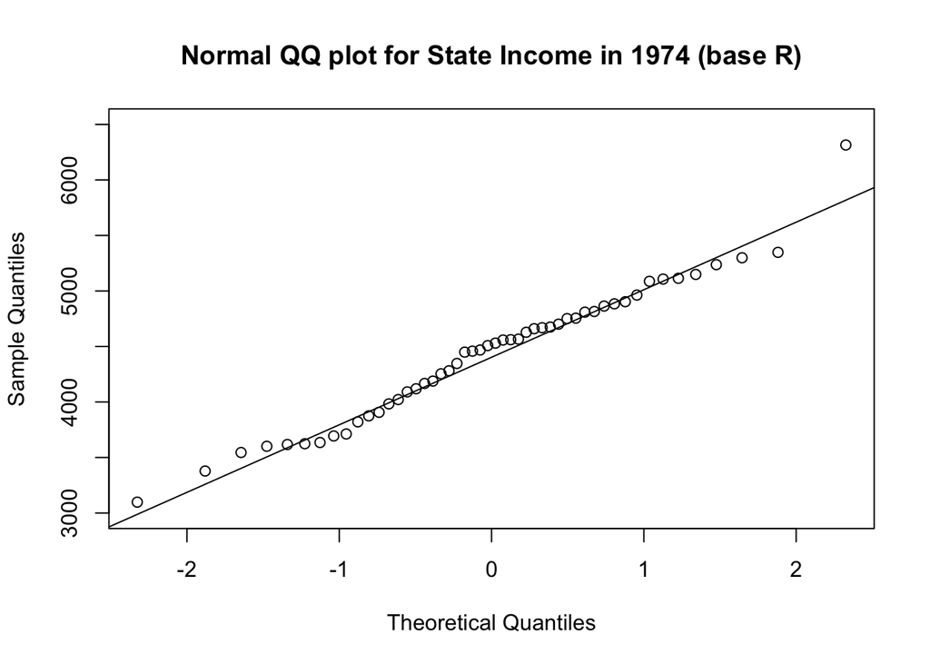

```r
qqnorm(y = income,
       ylim = c(3000, 6500),
       main =  "Normal QQ plot for State Income in 1974 (base R)")
qqline(y = income)
```

ggplot qq plot

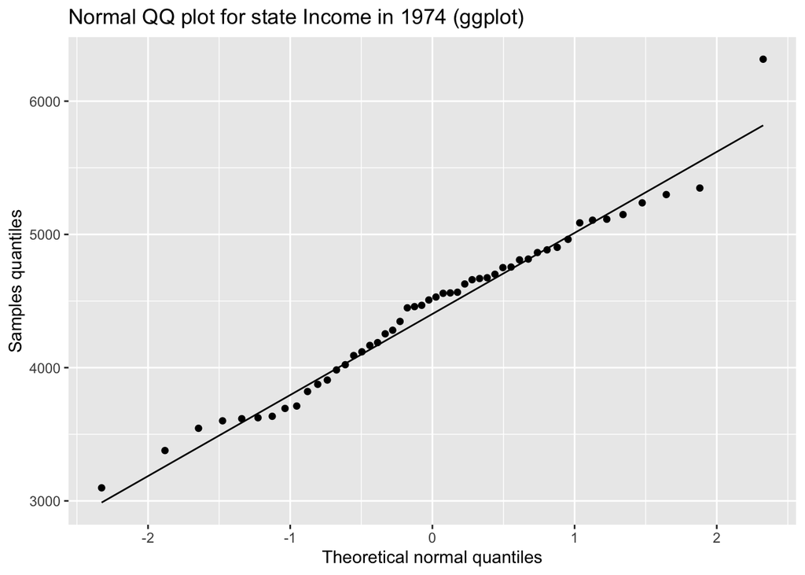

```r
ggplot(data = states, mapping = aes(sample = income)) +
  geom_qq(distribution = stats::qnorm) +
  geom_qq_line(distribution = stats::qnorm) +
  xlab("Theoretical normal quantiles") +
  ylab("Samples quantiles") +
  ggtitle("Normal QQ plot for state Income in 1974 (ggplot)")
```

The QQ plot indicates the hypothesis that the distribution of income is normally distributed. The plots showed how scattered each point is aligned with the straight line. As each point is close to the straight line, that means the income is more likely to be normal distributed. As we can see from this plot, each point is close to the straight line, except the biggest num, which would be a outlier if we used in boxplot. We can also check if the income is normally distributed by using Shapiro-wilk normality test:

```r
shapiro.test(income)
```

```
##
##  Shapiro-Wilk normality test
##
## data:  income
## W = 0.9769, p-value = 0.43
```